# Audi results for JCP resubmission

# 1. Summary of new Audi analyses

Knowledge about the specific car attribute predicts loss aversion for that attribute much better than general car knowledge and education do.

For the other two loss aversion measures (model car and risky choice gambles), general car knowledge, car attribute knowledge, and education all predict lower loss aversion to roughly the same extent. This nicely addresses the reviewer and AE critiques that we aren’t tapping specific domain or attribute knowledge but rather “general knowledge”.

I think this nicely addresses reviewer 1 and the AE’s concerns. My only worry is that it might look bad that we didn’t discuss this “attribute knowledge” measure in the initial submission.

Together, this suggests that general knowledge/intelligence is predicting lower loss aversion (otherwise, why would education and car knowledge matter?). However, specific knowledge about the attribute itself drives loss aversion more than general knowledge, as implied by our preference construction account.

# 2. Descriptive Statistics

Load data in long form (“au”) and wide form (“aus”, one line per person; allows for easier analysis of the loss aversion measures that are 1 per person)

## 2.1 Lambda violin plots for the three loss aversion measures

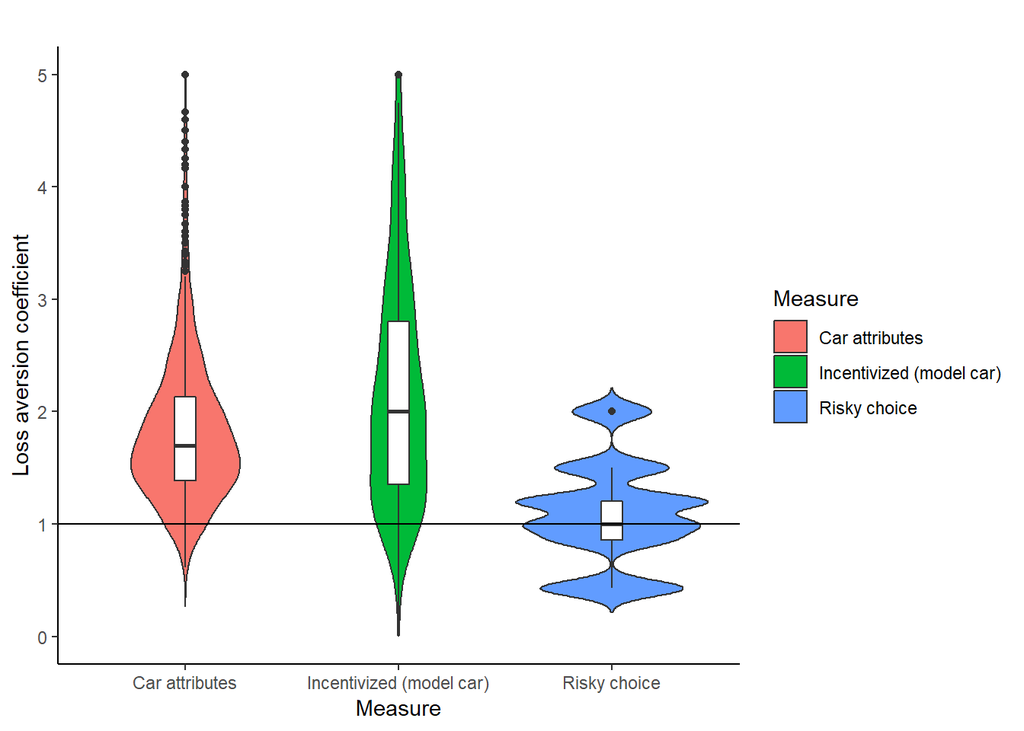

```r
ddee
```

## 2.2 Lambda violin plots for the four car attributes

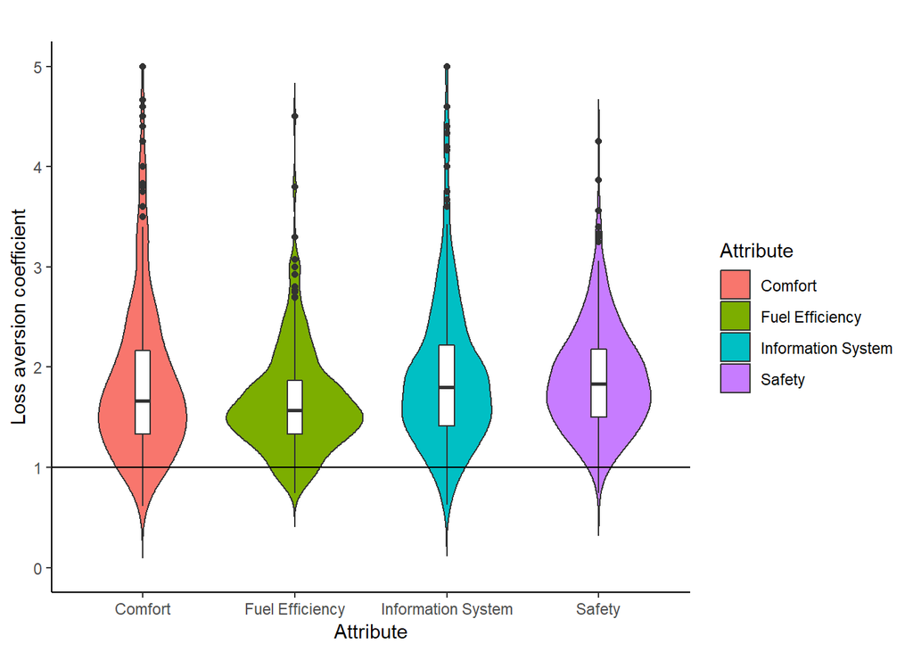

```r
ppdd
```

## 2.3 Density plots for car knowledge and attribute knowledge

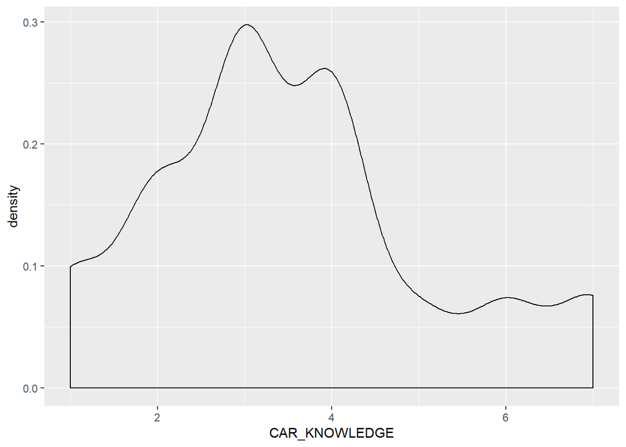

```r
ggplot(aus, aes(x=CAR_KNOWLEDGE)) +
  geom_density()
```

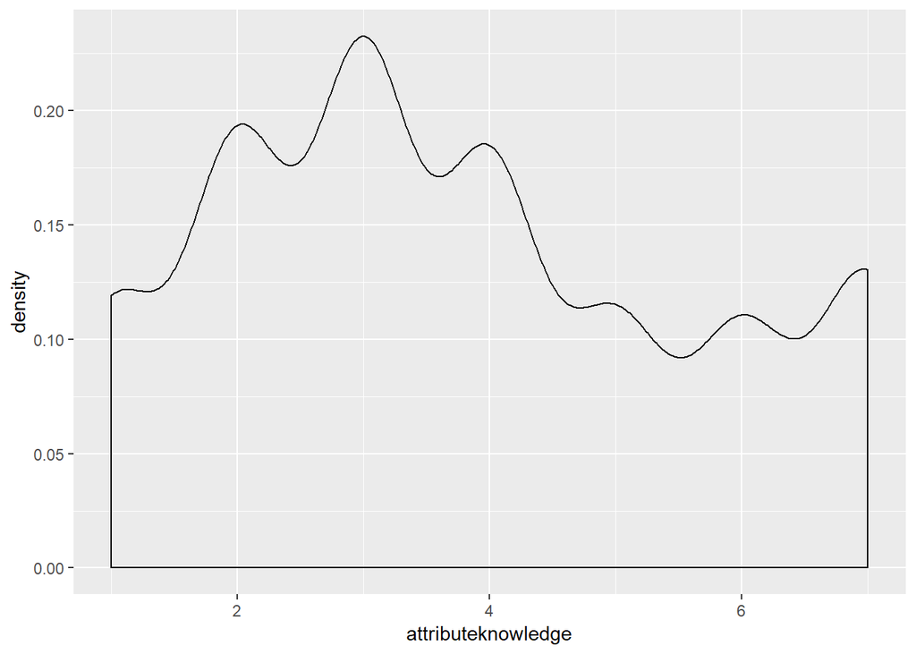

```r
ggplot(au, aes(x=attributeknowledge)) +
  geom_density()
```

# 3. Inferential analyses

## 3.1 Original models in main text (does not include attribute-level car knowledge):

(AE and reviewer critiques were that, contrary to our hypothesis, we were probably just tapping general knowledge/intelligence/numeracy rather than specific domain or attribute knowledge. Why else would “car knowledge” and “car use” predict loss aversion for gambles and for a model car, they ask)

First model below: attribute-level loss aversion

Second model below: risky choice loss aversion (coin flip gambles)

Third model below: model car loss aversion (incentivized)

```r
m1 <- lmer(attributelambda ~ AGE+CARUSE+CAR_KNOWLEDGE+EDUC+(1|RESPONDE),data=au)
summary(m1)
```

```
## Linear mixed model fit by REML. t-tests use Satterthwaite's method [
## lmerModLmerTest]
## Formula: attributelambda ~ AGE + CARUSE + CAR_KNOWLEDGE + EDUC + (1 |
##     RESPONDE)
##    Data: au
##
## REML criterion at convergence: 3008.6
##
## Scaled residuals:
##     Min      1Q  Median      3Q     Max
## -2.0073 -0.6313 -0.2076  0.3985  6.8256
##
## Random effects:
##  Groups   Name        Variance Std.Dev.
##  RESPONDE (Intercept) 0.0000   0.0000
##  Residual             0.4645   0.6816
## Number of obs: 1440, groups:  RESPONDE, 360
##
## Fixed effects:
##                 Estimate Std. Error         df t value Pr(>|t|)
## (Intercept)    1.958e+00  1.048e-01  1.435e+03  18.675  < 2e-16 ***
## AGE            7.690e-02  1.573e-02  1.435e+03   4.889 1.13e-06 ***
## CARUSE        -5.857e-02  1.969e-02  1.435e+03  -2.975  0.00298 **
## CAR_KNOWLEDGE -5.713e-02  1.436e-02  1.435e+03  -3.978 7.30e-05 ***
## EDUC           5.862e-03  2.947e-02  1.435e+03   0.199  0.84236
## ---
## Signif. codes:  0 '***' 0.001 '**' 0.01 '*' 0.05 '.' 0.1 ' ' 1
##
## Correlation of Fixed Effects:
##             (Intr) AGE    CARUSE CAR_KN
## AGE         -0.695
## CARUSE      -0.409  0.169
## CAR_KNOWLED -0.333  0.272 -0.511
## EDUC        -0.393 -0.130 -0.089  0.040
## convergence code: 0
## singular fit
```

```r
m2 <- lm(fehrlambda ~ AGE+CARUSE+CAR_KNOWLEDGE+EDUC,data=aus)
summary(m2)
```

```
##
## Call:
## lm(formula = fehrlambda ~ AGE + CARUSE + CAR_KNOWLEDGE + EDUC,
##     data = aus)
##
## Residuals:
##      Min       1Q   Median       3Q      Max
## -1.10289 -0.24029 -0.02286  0.23953  1.13297
##
## Coefficients:
##               Estimate Std. Error t value Pr(>|t|)
## (Intercept)    1.64980    0.11403  14.468  < 2e-16 ***
## AGE            0.04897    0.01711   2.863  0.00445 **
## CARUSE        -0.10392    0.02141  -4.854 1.82e-06 ***
## CAR_KNOWLEDGE -0.07538    0.01562  -4.826 2.08e-06 ***
## EDUC          -0.06749    0.03206  -2.105  0.03596 *
## ---
## Signif. codes:  0 '***' 0.001 '**' 0.01 '*' 0.05 '.' 0.1 ' ' 1
##
## Residual standard error: 0.3707 on 355 degrees of freedom
## Multiple R-squared:  0.3156, Adjusted R-squared:  0.3079
## F-statistic: 40.92 on 4 and 355 DF,  p-value: < 2.2e-16
```

```r
m3 <- lm(CALCLAMBDAMOD ~ AGE+CARUSE+CAR_KNOWLEDGE+EDUC,data=aus)
summary(m3)
```

```
##
## Call:
## lm(formula = CALCLAMBDAMOD ~ AGE + CARUSE + CAR_KNOWLEDGE + EDUC,
##     data = aus)
##
## Residuals:
##     Min      1Q  Median      3Q     Max
## -3.0989 -1.0131 -0.3582  0.4074 11.7883
##
## Coefficients:
##               Estimate Std. Error t value Pr(>|t|)
## (Intercept)    4.40570    0.62232   7.080 8.26e-12 ***
## AGE            0.38234    0.09313   4.105 5.05e-05 ***
## CARUSE        -0.28194    0.11624  -2.425 0.015804 *
## CAR_KNOWLEDGE -0.29416    0.08525  -3.450 0.000630 ***
## EDUC          -0.63002    0.17487  -3.603 0.000361 ***
## ---
## Signif. codes:  0 '***' 0.001 '**' 0.01 '*' 0.05 '.' 0.1 ' ' 1
##
## Residual standard error: 2.002 on 342 degrees of freedom
##   (13 observations deleted due to missingness)
## Multiple R-squared:  0.2292, Adjusted R-squared:  0.2202
## F-statistic: 25.42 on 4 and 342 DF,  p-value: < 2.2e-16
```

## 3.2 New model estimating attribute-level loss aversion, with attribute-level knowledge as a predictor

This shows that **specific knowledge** (attribute knowledge) seems to matter much more than education or generic car knowledge. This nicely addresses the AE and reviewer critiques that our effects are probably driven by general knowledge, not domain or specific knowledge that would determine whether preferences are constructed.

```r
m1a <- lmer(attributelambda ~ attributeknowledge+AGE+CARUSE+CAR_KNOWLEDGE+EDUC+(1|RESPONDE),data=au)
```

```
## singular fit
```

```r
summary(m1a)
```

```
## Linear mixed model fit by REML. t-tests use Satterthwaite's method [
## lmerModLmerTest]
## Formula:
## attributelambda ~ attributeknowledge + AGE + CARUSE + CAR_KNOWLEDGE +
##     EDUC + (1 | RESPONDE)
##    Data: au
##
## REML criterion at convergence: 2597.6
##
## Scaled residuals:
##     Min      1Q  Median      3Q     Max
## -1.9962 -0.5744 -0.1942  0.3410  7.1115
##
## Random effects:
##  Groups   Name        Variance Std.Dev.
##  RESPONDE (Intercept) 0.0000   0.0000
##  Residual             0.3472   0.5893
## Number of obs: 1440, groups:  RESPONDE, 360
##
## Fixed effects:
##                      Estimate Std. Error         df t value Pr(>|t|)
## (Intercept)         2.433e+00  9.317e-02  1.434e+03  26.110  < 2e-16 ***
## attributeknowledge -1.976e-01  8.967e-03  1.434e+03 -22.039  < 2e-16 ***
## AGE                 5.177e-02  1.365e-02  1.434e+03   3.794 0.000155 ***
## CARUSE             -6.718e-03  1.718e-02  1.434e+03  -0.391 0.695827
## CAR_KNOWLEDGE      -9.567e-03  1.260e-02  1.434e+03  -0.759 0.447908
## EDUC                1.833e-02  2.549e-02  1.434e+03   0.719 0.472201
## ---
## Signif. codes:  0 '***' 0.001 '**' 0.01 '*' 0.05 '.' 0.1 ' ' 1
##
## Correlation of Fixed Effects:
##             (Intr) attrbt AGE    CARUSE CAR_KN
## attrbtknwld -0.231
## AGE         -0.693  0.084
## CARUSE      -0.363 -0.137  0.155
## CAR_KNOWLED -0.280 -0.171  0.253 -0.475
## EDUC        -0.377 -0.022 -0.131 -0.085  0.043
## convergence code: 0
## singular fit
```

## 3.2.1 Different way of analyzing this: interaction by same vs. different attribute

```r
aul$dummysame<-aul$same+.5
aul$dummydifferent<-(aul$same-.5)*-1

aul$attributeknowledge_C<-aul$attributeknowledge-mean(aul$attributeknowledge,na.rm=TRUE)

m1b <- lmer(attlambda_extralong ~ attributeknowledge_C*dummydifferent+AGE+EDUC+CARUSE+CAR_KNOWLEDGE+(1|RESPONDE),data=aul,control=lmerControl(optimizer="bobyqa",optCtrl=list(maxfun=2e5)))
summary(m1b)
```

```
## Linear mixed model fit by REML. t-tests use Satterthwaite's method [
## lmerModLmerTest]
## Formula: attlambda_extralong ~ attributeknowledge_C * dummydifferent +
##     AGE + EDUC + CARUSE + CAR_KNOWLEDGE + (1 | RESPONDE)
##    Data: aul
## Control: lmerControl(optimizer = "bobyqa", optCtrl = list(maxfun = 2e+05))
##
## REML criterion at convergence: 11353.3
##
## Scaled residuals:
##     Min      1Q  Median      3Q     Max
## -3.4006 -0.6061 -0.1480  0.4266  6.3220
##
## Random effects:
##  Groups   Name        Variance Std.Dev.
##  RESPONDE (Intercept) 0.04709  0.2170
##  Residual             0.38971  0.6243
## Number of obs: 5760, groups:  RESPONDE, 360
##
## Fixed effects:
##                                       Estimate Std. Error         df
## (Intercept)                          1.946e+00  8.375e-02  3.760e+02
## attributeknowledge_C                -1.592e-01  9.145e-03  5.585e+03
## dummydifferent                      -5.023e-16  1.900e-02  5.392e+03
## AGE                                  7.580e-02  1.235e-02  3.517e+02
## EDUC                                 6.405e-03  2.312e-02  3.501e+02
## CARUSE                              -5.631e-02  1.550e-02  3.548e+02
## CAR_KNOWLEDGE                       -5.506e-02  1.133e-02  3.576e+02
## attributeknowledge_C:dummydifferent  2.008e-01  1.017e-02  5.392e+03
##                                     t value Pr(>|t|)
## (Intercept)                          23.238  < 2e-16 ***
## attributeknowledge_C                -17.410  < 2e-16 ***
## dummydifferent                        0.000 1.000000
## AGE                                   6.137 2.27e-09 ***
## EDUC                                  0.277 0.781922
## CARUSE                               -3.634 0.000321 ***
## CAR_KNOWLEDGE                        -4.860 1.76e-06 ***
## attributeknowledge_C:dummydifferent  19.751  < 2e-16 ***
## ---
## Signif. codes:  0 '***' 0.001 '**' 0.01 '*' 0.05 '.' 0.1 ' ' 1
##
## Correlation of Fixed Effects:
##             (Intr) attr_C dmmydf AGE    EDUC   CARUSE CAR_KN
## attrbtknw_C  0.046
## dummydffrnt -0.170  0.000
## AGE         -0.677  0.029  0.000
## EDUC        -0.387 -0.008  0.000 -0.130
## CARUSE      -0.408 -0.047  0.000  0.164 -0.087
## CAR_KNOWLED -0.334 -0.059  0.000  0.265  0.041 -0.497
## attrbtkn_C:  0.000 -0.834  0.000  0.000  0.000  0.000  0.000
```

## 3.2.2 Simple-effects tests

(effect of attribute knowledge on lambda when looking at knowledge of that same attribute=same vs. when looking at knowledge of a different attribute)

Effect of same attribute knowledge: (simple effect is in the att knowledge line: b = -.168)

```r
aul$dummysame<-aul$same+.5
aul$dummydifferent<-(aul$same-.5)*-1

m1b <- lmer(attlambda_extralong ~ attributeknowledge*dummydifferent+(1|RESPONDE),data=aul)
summary(m1b)
```

```
## Linear mixed model fit by REML. t-tests use Satterthwaite's method [
## lmerModLmerTest]
## Formula: attlambda_extralong ~ attributeknowledge * dummydifferent + (1 |
##     RESPONDE)
##    Data: aul
##
## REML criterion at convergence: 11485.9
##
## Scaled residuals:
##     Min      1Q  Median      3Q     Max
## -3.6010 -0.5979 -0.1372  0.4409  6.1906
##
## Random effects:
##  Groups   Name        Variance Std.Dev.
##  RESPONDE (Intercept) 0.08325  0.2885
##  Residual             0.39030  0.6247
## Number of obs: 5760, groups:  RESPONDE, 360
##
## Fixed effects:
##                                     Estimate Std. Error         df t value
## (Intercept)                        2.478e+00  4.109e-02  4.360e+03   60.32
## attributeknowledge                -1.679e-01  9.126e-03  5.617e+03  -18.40
## dummydifferent                    -7.578e-01  4.285e-02  5.376e+03  -17.69
## attributeknowledge:dummydifferent  2.008e-01  1.018e-02  5.376e+03   19.74
##                                   Pr(>|t|)
## (Intercept)                         <2e-16 ***
## attributeknowledge                  <2e-16 ***
## dummydifferent                      <2e-16 ***
## attributeknowledge:dummydifferent   <2e-16 ***
## ---
## Signif. codes:  0 '***' 0.001 '**' 0.01 '*' 0.05 '.' 0.1 ' ' 1
##
## Correlation of Fixed Effects:
##             (Intr) attrbt dmmydf
## attrbtknwld -0.838
## dummydffrnt -0.782  0.749
## attrbtknwl:  0.701 -0.836 -0.896
```

Simple effect of other attribute knowledge:

b = 0.03

(effect is much smaller and actually in opposite direction–if anything, more knowledge about the other attributes increases loss aversion whereas more knowledge about the same attribute greatly decreases loss aversion)

```r
m1b <- lmer(attlambda_extralong ~ attributeknowledge*dummysame+(1|RESPONDE),data=aul)
summary(m1b)
```

```
## Linear mixed model fit by REML. t-tests use Satterthwaite's method [
## lmerModLmerTest]
## Formula:
## attlambda_extralong ~ attributeknowledge * dummysame + (1 | RESPONDE)
##    Data: aul
##
## REML criterion at convergence: 11485.9
##
## Scaled residuals:
##     Min      1Q  Median      3Q     Max
## -3.6010 -0.5979 -0.1372  0.4409  6.1906
##
## Random effects:
##  Groups   Name        Variance Std.Dev.
##  RESPONDE (Intercept) 0.08325  0.2885
##  Residual             0.39030  0.6247
## Number of obs: 5760, groups:  RESPONDE, 360
##
## Fixed effects:
##                                Estimate Std. Error         df t value
## (Intercept)                   1.721e+00  2.775e-02  1.681e+03  61.993
## attributeknowledge            3.287e-02  5.613e-03  5.753e+03   5.856
## dummysame                     7.578e-01  4.285e-02  5.376e+03  17.687
## attributeknowledge:dummysame -2.008e-01  1.018e-02  5.376e+03 -19.736
##                              Pr(>|t|)
## (Intercept)                    <2e-16 ***
## attributeknowledge              5e-09 ***
## dummysame                      <2e-16 ***
## attributeknowledge:dummysame   <2e-16 ***
## ---
## Signif. codes:  0 '***' 0.001 '**' 0.01 '*' 0.05 '.' 0.1 ' ' 1
##
## Correlation of Fixed Effects:
##             (Intr) attrbt dmmysm
## attrbtknwld -0.763
## dummysame   -0.386  0.406
## attrbtknwl:  0.346 -0.453 -0.896
```

## 3.3 New models estimating risky choice and model car loss aversion, with attribute-level knowledge as a predictor

For the other loss aversion measures (risky choice gambles and model car), the attribute knowledge measure shouldn’t wipe out the other effects. Luckily, it doesn’t. (If it did, that might mean that attribute knowledge is just a better or more reliable measure of actual knowledge)

It’s also notable that all of these knowledge and experience measures still predict lower loss aversion even in other domains such as gambles/financial domain (albeit with smaller effect sizes than when you have a measure of loss aversion with the specific attribute you measured knowledge for). So we should acknowledge reviewers’ point that general knowledge, education, maybe numeracy, probably do explain some part of the effects.

```r
m2a <- lm(fehrlambda ~ AGE+CARUSE+CAR_KNOWLEDGE+avgKNOW+EDUC,data=aus)
summary(m2a)
```

```
##
## Call:
## lm(formula = fehrlambda ~ AGE + CARUSE + CAR_KNOWLEDGE + avgKNOW +
##     EDUC, data = aus)
##
## Residuals:
##      Min       1Q   Median       3Q      Max
## -1.04421 -0.25787 -0.01651  0.20853  1.09500
##
## Coefficients:
##               Estimate Std. Error t value Pr(>|t|)
## (Intercept)    1.94559    0.12753  15.256  < 2e-16 ***
## AGE            0.03331    0.01696   1.965  0.05022 .
## CARUSE        -0.07162    0.02192  -3.268  0.00119 **
## CAR_KNOWLEDGE -0.04575    0.01644  -2.782  0.00569 **
## avgKNOW       -0.12311    0.02627  -4.686 3.98e-06 ***
## EDUC          -0.05973    0.03119  -1.915  0.05634 .
## ---
## Signif. codes:  0 '***' 0.001 '**' 0.01 '*' 0.05 '.' 0.1 ' ' 1
##
## Residual standard error: 0.3602 on 354 degrees of freedom
## Multiple R-squared:  0.3555, Adjusted R-squared:  0.3464
## F-statistic: 39.06 on 5 and 354 DF,  p-value: < 2.2e-16
```

```r
m3a <- lm(CALCLAMBDAMOD ~ AGE+CARUSE+CAR_KNOWLEDGE+avgKNOW+EDUC,data=aus)
summary(m3a)
```

```
##
## Call:
## lm(formula = CALCLAMBDAMOD ~ AGE + CARUSE + CAR_KNOWLEDGE + avgKNOW +
##     EDUC, data = aus)
##
## Residuals:
##     Min      1Q  Median      3Q     Max
## -3.3588 -0.9881 -0.3951  0.4208 11.6923
##
## Coefficients:
##               Estimate Std. Error t value Pr(>|t|)
## (Intercept)    5.62613    0.70704   7.957 2.63e-14 ***
## AGE            0.31503    0.09372   3.361 0.000864 ***
## CARUSE        -0.14804    0.12080  -1.225 0.221249
## CAR_KNOWLEDGE -0.17016    0.09126  -1.864 0.063115 .
## avgKNOW       -0.50681    0.14661  -3.457 0.000616 ***
## EDUC          -0.60202    0.17232  -3.494 0.000539 ***
## ---
## Signif. codes:  0 '***' 0.001 '**' 0.01 '*' 0.05 '.' 0.1 ' ' 1
##
## Residual standard error: 1.97 on 341 degrees of freedom
##   (13 observations deleted due to missingness)
## Multiple R-squared:  0.2553, Adjusted R-squared:  0.2444
## F-statistic: 23.38 on 5 and 341 DF,  p-value: < 2.2e-16
```

# 4. Robustness, covariates etc.

Below, I simply add domain knowledge to all the other analyses from the initial submission where we add covariates.

There don’t seem to be any changes, which is good. The effects hold when adding the covariates.

## 4.1 Adding covariates to new models (income, wealth, gender)

The effects hold when adding the covariates.

```r
m1c <- lmer(attributelambda ~ attributeknowledge+AGE+CARUSE+CAR_KNOWLEDGE+EDUC+INCOME+WEALTH+GENDER+(1|RESPONDE),data=au)
summary(m1c)
```

```
## Linear mixed model fit by REML. t-tests use Satterthwaite's method [
## lmerModLmerTest]
## Formula:
## attributelambda ~ attributeknowledge + AGE + CARUSE + CAR_KNOWLEDGE +
##     EDUC + INCOME + WEALTH + GENDER + (1 | RESPONDE)
##    Data: au
##
## REML criterion at convergence: 2609.5
##
## Scaled residuals:
##     Min      1Q  Median      3Q     Max
## -2.0610 -0.5804 -0.1889  0.3346  7.0567
##
## Random effects:
##  Groups   Name        Variance Std.Dev.
##  RESPONDE (Intercept) 0.0000   0.0000
##  Residual             0.3466   0.5887
## Number of obs: 1440, groups:  RESPONDE, 360
##
## Fixed effects:
##                      Estimate Std. Error         df t value Pr(>|t|)
## (Intercept)         2.303e+00  1.200e-01  1.431e+03  19.195  < 2e-16 ***
## attributeknowledge -1.959e-01  8.999e-03  1.431e+03 -21.771  < 2e-16 ***
## AGE                 4.055e-02  1.478e-02  1.431e+03   2.743  0.00617 **
## CARUSE             -2.102e-03  1.738e-02  1.431e+03  -0.121  0.90372
## CAR_KNOWLEDGE      -1.067e-03  1.331e-02  1.431e+03  -0.080  0.93614
## EDUC                5.574e-03  2.669e-02  1.431e+03   0.209  0.83461
## INCOME              1.921e-02  1.730e-02  1.431e+03   1.111  0.26692
## WEALTH              2.467e-02  1.477e-02  1.431e+03   1.670  0.09517 .
## GENDER             -1.011e-02  3.602e-02  1.431e+03  -0.281  0.77897
## ---
## Signif. codes:  0 '***' 0.001 '**' 0.01 '*' 0.05 '.' 0.1 ' ' 1
##
## Correlation of Fixed Effects:
##             (Intr) attrbt AGE    CARUSE CAR_KN EDUC   INCOME WEALTH
## attrbtknwld -0.232
## AGE         -0.290  0.040
## CARUSE      -0.373 -0.120  0.085
## CAR_KNOWLED -0.353 -0.132  0.098 -0.400
## EDUC        -0.158 -0.047 -0.005 -0.118 -0.056
## INCOME      -0.298  0.075 -0.324  0.109  0.287 -0.290
## WEALTH      -0.289  0.027 -0.087  0.040  0.054  0.019 -0.312
## GENDER      -0.373  0.020 -0.057  0.073 -0.015  0.009 -0.083  0.060
## convergence code: 0
## singular fit
```

```r
m2c <- lm(fehrlambda ~ AGE+CARUSE+CAR_KNOWLEDGE+EDUC+INCOME+WEALTH+GENDER+(1|RESPONDE),data=aus)
summary(m2c)
```

```
##
## Call:
## lm(formula = fehrlambda ~ AGE + CARUSE + CAR_KNOWLEDGE + EDUC +
##     INCOME + WEALTH + GENDER + (1 | RESPONDE), data = aus)
##
## Residuals:
##      Min       1Q   Median       3Q      Max
## -0.96420 -0.23674 -0.02522  0.24941  1.14774
##
## Coefficients: (1 not defined because of singularities)
##                   Estimate Std. Error t value Pr(>|t|)
## (Intercept)       1.218785   0.141271   8.627  < 2e-16 ***
## AGE               0.009483   0.017881   0.530 0.596205
## CARUSE           -0.085148   0.020881  -4.078 5.62e-05 ***
## CAR_KNOWLEDGE    -0.045410   0.015972  -2.843 0.004728 **
## EDUC             -0.116433   0.032275  -3.608 0.000354 ***
## INCOME            0.090063   0.020875   4.314 2.08e-05 ***
## WEALTH            0.036200   0.017876   2.025 0.043621 *
## GENDER            0.030559   0.043589   0.701 0.483724
## 1 | RESPONDETRUE        NA         NA      NA       NA
## ---
## Signif. codes:  0 '***' 0.001 '**' 0.01 '*' 0.05 '.' 0.1 ' ' 1
##
## Residual standard error: 0.3563 on 352 degrees of freedom
## Multiple R-squared:  0.373,  Adjusted R-squared:  0.3605
## F-statistic: 29.91 on 7 and 352 DF,  p-value: < 2.2e-16
```

```r
m3c <- lm(CALCLAMBDAMOD ~ AGE+CARUSE+CAR_KNOWLEDGE+EDUC+INCOME+WEALTH+GENDER+(1|RESPONDE),data=aus)
summary(m3c)
```

```
##
## Call:
## lm(formula = CALCLAMBDAMOD ~ AGE + CARUSE + CAR_KNOWLEDGE + EDUC +
##     INCOME + WEALTH + GENDER + (1 | RESPONDE), data = aus)
##
## Residuals:
##     Min      1Q  Median      3Q     Max
## -3.1506 -1.0403 -0.3219  0.3948 11.7143
##
## Coefficients: (1 not defined because of singularities)
##                  Estimate Std. Error t value Pr(>|t|)
## (Intercept)       3.29656    0.79445   4.149 4.22e-05 ***
## AGE               0.26461    0.10091   2.622  0.00913 **
## CARUSE           -0.23299    0.11687  -1.994  0.04701 *
## CAR_KNOWLEDGE    -0.20636    0.08973  -2.300  0.02206 *
## EDUC             -0.77717    0.18156  -4.281 2.43e-05 ***
## INCOME            0.28411    0.11776   2.413  0.01637 *
## WEALTH            0.09195    0.10181   0.903  0.36709
## GENDER           -0.02927    0.24568  -0.119  0.90525
## 1 | RESPONDETRUE       NA         NA      NA       NA
## ---
## Signif. codes:  0 '***' 0.001 '**' 0.01 '*' 0.05 '.' 0.1 ' ' 1
##
## Residual standard error: 1.985 on 339 degrees of freedom
##   (13 observations deleted due to missingness)
## Multiple R-squared:  0.2486, Adjusted R-squared:  0.233
## F-statistic: 16.02 on 7 and 339 DF,  p-value: < 2.2e-16
```

## 4.2 Other robustness tests, in Supplemental Material

Effects hold when using different probability weighting functions, diminishing marginal utility, etc.

```r
aus$kandt<-NA
aus$kandt[aus$fehrlambda==.4285]<-.419432
aus$kandt[aus$fehrlambda==.857]<-.771912
aus$kandt[aus$fehrlambda==1]<-.884058
aus$kandt[aus$fehrlambda==1.2]<-1.037911
aus$kandt[aus$fehrlambda==1.5]<-1.26311
aus$kandt[aus$fehrlambda==2]<-1.627


aus$valueonly<-NA
aus$valueonly[aus$fehrlambda==.4285]<-.483956
aus$valueonly[aus$fehrlambda==.857]<-.915701
aus$valueonly[aus$fehrlambda==1]<-1.055224
aus$valueonly[aus$fehrlambda==1.2]<-1.247933
aus$valueonly[aus$fehrlambda==1.5]<-1.532317
aus$valueonly[aus$fehrlambda==2]<-1.996605


#add probability
aus$addprobability<-NA
aus$addprobability[aus$fehrlambda==.4285]<-.416202
aus$addprobability[aus$fehrlambda==.857]<-.787503
aus$addprobability[aus$fehrlambda==1]<-.907492
aus$addprobability[aus$fehrlambda==1.2]<-1.07322
aus$addprobability[aus$fehrlambda==1.5]<-1.317792
aus$addprobability[aus$fehrlambda==2]<-1.71708


#2.58   1.72    1.29    1.032   0.86    0.7482


#only probability
aus$onlyprobability<-NA
aus$onlyprobability[aus$fehrlambda==.4285]<-.368571
aus$onlyprobability[aus$fehrlambda==.857]<-.7482
aus$onlyprobability[aus$fehrlambda==1]<-.86
aus$onlyprobability[aus$fehrlambda==1.2]<-1.032
aus$onlyprobability[aus$fehrlambda==1.5]<-1.29
aus$onlyprobability[aus$fehrlambda==2]<-1.72



m2d1 <- lm(kandt ~ AGE+EDUC+attributeknowledge+CARUSE+CAR_KNOWLEDGE,data=aus)
summary(m2d1)
```

```
##
## Call:
## lm(formula = kandt ~ AGE + EDUC + attributeknowledge + CARUSE +
##     CAR_KNOWLEDGE, data = aus)
##
## Residuals:
##      Min       1Q   Median       3Q      Max
## -0.87211 -0.18146 -0.01398  0.19000  0.86666
##
## Coefficients:
##                     Estimate Std. Error t value Pr(>|t|)
## (Intercept)         1.391636   0.092711  15.010  < 2e-16 ***
## AGE                 0.037369   0.013275   2.815  0.00515 **
## EDUC               -0.051631   0.024708  -2.090  0.03736 *
## attributeknowledge -0.004674   0.008899  -0.525  0.59974
## CARUSE             -0.079590   0.016539  -4.812 2.21e-06 ***
## CAR_KNOWLEDGE      -0.057368   0.012289  -4.668 4.32e-06 ***
## ---
## Signif. codes:  0 '***' 0.001 '**' 0.01 '*' 0.05 '.' 0.1 ' ' 1
##
## Residual standard error: 0.2856 on 354 degrees of freedom
## Multiple R-squared:  0.3193, Adjusted R-squared:  0.3097
## F-statistic: 33.22 on 5 and 354 DF,  p-value: < 2.2e-16
```

```r
m2d2 <- lm(valueonly ~ AGE+EDUC+attributeknowledge+CARUSE+CAR_KNOWLEDGE,data=aus)
summary(m2d2)
```

```
##
## Call:
## lm(formula = valueonly ~ AGE + EDUC + attributeknowledge + CARUSE +
##     CAR_KNOWLEDGE, data = aus)
##
## Residuals:
##      Min       1Q   Median       3Q      Max
## -1.08386 -0.22941 -0.02088  0.23445  1.09239
##
## Coefficients:
##                     Estimate Std. Error t value Pr(>|t|)
## (Intercept)         1.694041   0.116051  14.597  < 2e-16 ***
## AGE                 0.046576   0.016617   2.803  0.00534 **
## EDUC               -0.064889   0.030928  -2.098  0.03661 *
## attributeknowledge -0.005817   0.011139  -0.522  0.60182
## CARUSE             -0.099561   0.020703  -4.809 2.25e-06 ***
## CAR_KNOWLEDGE      -0.071559   0.015383  -4.652 4.65e-06 ***
## ---
## Signif. codes:  0 '***' 0.001 '**' 0.01 '*' 0.05 '.' 0.1 ' ' 1
##
## Residual standard error: 0.3575 on 354 degrees of freedom
## Multiple R-squared:  0.3183, Adjusted R-squared:  0.3087
## F-statistic: 33.06 on 5 and 354 DF,  p-value: < 2.2e-16
```

```r
m2d3 <- lm(onlyprobability ~ AGE+EDUC+attributeknowledge+CARUSE+CAR_KNOWLEDGE,data=aus)
summary(m2d3)
```

```
##
## Call:
## lm(formula = onlyprobability ~ AGE + EDUC + attributeknowledge +
##     CARUSE + CAR_KNOWLEDGE, data = aus)
##
## Residuals:
##      Min       1Q   Median       3Q      Max
## -0.95410 -0.20525 -0.02517  0.20116  0.98550
##
## Coefficients:
##                     Estimate Std. Error t value Pr(>|t|)
## (Intercept)         1.436631   0.103327  13.904  < 2e-16 ***
## AGE                 0.041049   0.014795   2.774  0.00582 **
## EDUC               -0.058035   0.027537  -2.108  0.03577 *
## attributeknowledge -0.005094   0.009918  -0.514  0.60781
## CARUSE             -0.088406   0.018433  -4.796 2.39e-06 ***
## CAR_KNOWLEDGE      -0.063490   0.013696  -4.636 5.01e-06 ***
## ---
## Signif. codes:  0 '***' 0.001 '**' 0.01 '*' 0.05 '.' 0.1 ' ' 1
##
## Residual standard error: 0.3183 on 354 degrees of freedom
## Multiple R-squared:  0.3165, Adjusted R-squared:  0.3068
## F-statistic: 32.78 on 5 and 354 DF,  p-value: < 2.2e-16
```

```r
m2d4 <- lm(addprobability ~ AGE+EDUC+attributeknowledge+CARUSE+CAR_KNOWLEDGE,data=aus)
summary(m2d4)
```

```
##
## Call:
## lm(formula = addprobability ~ AGE + EDUC + attributeknowledge +
##     CARUSE + CAR_KNOWLEDGE, data = aus)
##
## Residuals:
##      Min       1Q   Median       3Q      Max
## -0.93211 -0.19730 -0.01796  0.20162  0.93946
##
## Coefficients:
##                     Estimate Std. Error t value Pr(>|t|)
## (Intercept)         1.456874   0.099804  14.597  < 2e-16 ***
## AGE                 0.040055   0.014291   2.803  0.00534 **
## EDUC               -0.055805   0.026598  -2.098  0.03661 *
## attributeknowledge -0.005003   0.009580  -0.522  0.60182
## CARUSE             -0.085622   0.017805  -4.809 2.25e-06 ***
## CAR_KNOWLEDGE      -0.061541   0.013229  -4.652 4.65e-06 ***
## ---
## Signif. codes:  0 '***' 0.001 '**' 0.01 '*' 0.05 '.' 0.1 ' ' 1
##
## Residual standard error: 0.3075 on 354 degrees of freedom
## Multiple R-squared:  0.3183, Adjusted R-squared:  0.3087
## F-statistic: 33.06 on 5 and 354 DF,  p-value: < 2.2e-16
```

## 4.3 Supp mat: differences across the 3 between-subjects level of comparison groups

(For each attribute, some participants gave WTA/WTP for changes from high to medium level of each attribute, medium to low, or high to low).

```r
m7 <- lmer(attributelambda ~ dummyHL+dummyHM +
              (1|RESPONDE),
            data=au, verbose=T,
            control=lmerControl(optCtrl=list(maxfun=100000)))
```

[output not shown]

```r
summary(m7)
```

```
## Linear mixed model fit by REML. t-tests use Satterthwaite's method [
## lmerModLmerTest]
## Formula: attributelambda ~ dummyHL + dummyHM + (1 | RESPONDE)
##    Data: au
## Control: lmerControl(optCtrl = list(maxfun = 1e+05))
##
## REML criterion at convergence: 3106.3
##
## Scaled residuals:
##     Min      1Q  Median      3Q     Max
## -1.8082 -0.6368 -0.1948  0.4093  6.7440
##
## Random effects:
##  Groups   Name        Variance Std.Dev.
##  RESPONDE (Intercept) 0.000    0.0000
##  Residual             0.502    0.7085
## Number of obs: 1440, groups:  RESPONDE, 360
##
## Fixed effects:
##               Estimate Std. Error         df t value Pr(>|t|)
## (Intercept)  1.897e+00  3.234e-02  1.437e+03  58.644  < 2e-16 ***
## dummyHL     -1.477e-01  4.573e-02  1.437e+03  -3.230  0.00127 **
## dummyHM     -8.127e-03  4.573e-02  1.437e+03  -0.178  0.85898
## ---
## Signif. codes:  0 '***' 0.001 '**' 0.01 '*' 0.05 '.' 0.1 ' ' 1
##
## Correlation of Fixed Effects:
##         (Intr) dmmyHL
## dummyHL -0.707
## dummyHM -0.707  0.500
## convergence code: 0
## singular fit
```

## 4.4 Getting Cohen’s d for key models

```r
aul$CAR_KNOWLEDGE_st<-(aul$CAR_KNOWLEDGE-mean(aul$CAR_KNOWLEDGE,na.rm=TRUE))/(sd(aul$CAR_KNOWLEDGE,na.rm=TRUE))

aul$CARUSE_st<-(aul$CARUSE-mean(aul$CARUSE,na.rm=TRUE))/(sd(aul$CARUSE,na.rm=TRUE))

aul$EDUC_st<-(aul$EDUC-mean(aul$EDUC,na.rm=TRUE))/(sd(aul$EDUC,na.rm=TRUE))

aul$AGE_st<-(aul$AGE-mean(aul$AGE,na.rm=TRUE))/(sd(aul$AGE,na.rm=TRUE))

aul$attributeknowledge_st<-(aul$attributeknowledge-mean(aul$attributeknowledge,na.rm=TRUE))/(sd(aul$attributeknowledge,na.rm=TRUE))

aul$attributelambda_st<-(aul$attlambda_extralong-mean(aul$attlambda_extralong,na.rm=TRUE))/(sd(aul$attlambda_extralong,na.rm=TRUE))



aus$avgKNOW_st<-(aus$avgKNOW-mean(aus$avgKNOW,na.rm=TRUE))/(sd(aus$avgKNOW,na.rm=TRUE))

aus$CAR_KNOWLEDGE_st<-(aus$CAR_KNOWLEDGE-mean(aus$CAR_KNOWLEDGE,na.rm=TRUE))/(sd(aus$CAR_KNOWLEDGE,na.rm=TRUE))

aus$CARUSE_st<-(aus$CARUSE-mean(aus$CARUSE,na.rm=TRUE))/(sd(aus$CARUSE,na.rm=TRUE))

aus$EDUC_st<-(aus$EDUC-mean(aus$EDUC,na.rm=TRUE))/(sd(aus$EDUC,na.rm=TRUE))

aus$AGE_st<-(aus$AGE-mean(aus$AGE,na.rm=TRUE))/(sd(aus$AGE,na.rm=TRUE))

aus$CALCLAMBDAMOD_st<-(aus$CALCLAMBDAMOD-mean(aus$CALCLAMBDAMOD,na.rm=TRUE))/(sd(aus$CALCLAMBDAMOD,na.rm=TRUE))

aus$fehrlambda_st<-(aus$fehrlambda-mean(aus$fehrlambda,na.rm=TRUE))/(sd(aus$fehrlambda,na.rm=TRUE))

aus$INCOME_st<-scale(aus$INCOME)

aus$WEALTH_st<-scale(aus$WEALTH)

aus$GENDER_st<-scale(aus$GENDER)


m1a <- lmer(attributelambda_st ~ attributeknowledge_st*dummydifferent+AGE_st+CARUSE_st+CAR_KNOWLEDGE_st+EDUC_st+(1|RESPONDE),data=aul)
summary(m1a)
```

```
## Linear mixed model fit by REML. t-tests use Satterthwaite's method [
## lmerModLmerTest]
## Formula: attributelambda_st ~ attributeknowledge_st * dummydifferent +
##     AGE_st + CARUSE_st + CAR_KNOWLEDGE_st + EDUC_st + (1 | RESPONDE)
##    Data: aul
##
## REML criterion at convergence: 15272.4
##
## Scaled residuals:
##     Min      1Q  Median      3Q     Max
## -3.4006 -0.6061 -0.1480  0.4266  6.3220
##
## Random effects:
##  Groups   Name        Variance Std.Dev.
##  RESPONDE (Intercept) 0.09313  0.3052
##  Residual             0.77071  0.8779
## Number of obs: 5760, groups:  RESPONDE, 360
##
## Fixed effects:
##                                        Estimate Std. Error         df
## (Intercept)                          -1.529e-18  2.818e-02  1.343e+03
## attributeknowledge_st                -4.183e-01  2.403e-02  5.585e+03
## dummydifferent                        3.990e-17  2.671e-02  5.392e+03
## AGE_st                                1.374e-01  2.239e-02  3.517e+02
## CARUSE_st                            -9.058e-02  2.493e-02  3.548e+02
## CAR_KNOWLEDGE_st                     -1.244e-01  2.561e-02  3.576e+02
## EDUC_st                               5.555e-03  2.005e-02  3.501e+02
## attributeknowledge_st:dummydifferent  5.277e-01  2.672e-02  5.392e+03
##                                      t value Pr(>|t|)
## (Intercept)                            0.000 1.000000
## attributeknowledge_st                -17.410  < 2e-16 ***
## dummydifferent                         0.000 1.000000
## AGE_st                                 6.137 2.27e-09 ***
## CARUSE_st                             -3.634 0.000321 ***
## CAR_KNOWLEDGE_st                      -4.860 1.76e-06 ***
## EDUC_st                                0.277 0.781922
## attributeknowledge_st:dummydifferent  19.751  < 2e-16 ***
## ---
## Signif. codes:  0 '***' 0.001 '**' 0.01 '*' 0.05 '.' 0.1 ' ' 1
##
## Correlation of Fixed Effects:
##             (Intr) attrb_ dmmydf AGE_st CARUSE CAR_KN EDUC_s
## attrbtknwl_  0.000
## dummydffrnt -0.711  0.000
## AGE_st       0.000  0.029  0.000
## CARUSE_st    0.000 -0.047  0.000  0.164
## CAR_KNOWLED  0.000 -0.059  0.000  0.265 -0.497
## EDUC_st      0.000 -0.008  0.000 -0.130 -0.087  0.041
## attrbtknw_:  0.000 -0.834  0.000  0.000  0.000  0.000  0.000
```

```r
confint(m1a,method='Wald')
```

```
##                                            2.5 %      97.5 %
## .sig01                                        NA          NA
## .sigma                                        NA          NA
## (Intercept)                          -0.05522475  0.05522475
## attributeknowledge_st                -0.46543971 -0.37124616
## dummydifferent                       -0.05235780  0.05235780
## AGE_st                                0.09351953  0.18129109
## CARUSE_st                            -0.13944302 -0.04172409
## CAR_KNOWLEDGE_st                     -0.17463865 -0.07425564
## EDUC_st                              -0.03374913  0.04486005
## attributeknowledge_st:dummydifferent  0.47530246  0.58002716
```

```r
m2a <- lm(fehrlambda_st ~ AGE_st+CARUSE_st+CAR_KNOWLEDGE_st+avgKNOW_st+EDUC_st,data=aus)
summary(m2a)
```

```
##
## Call:
## lm(formula = fehrlambda_st ~ AGE_st + CARUSE_st + CAR_KNOWLEDGE_st +
##     avgKNOW_st + EDUC_st, data = aus)
##
## Residuals:
##      Min       1Q   Median       3Q      Max
## -2.34374 -0.57879 -0.03707  0.46805  2.45775
##
## Coefficients:
##                    Estimate Std. Error t value Pr(>|t|)
## (Intercept)       1.135e-16  4.261e-02   0.000  1.00000
## AGE_st            9.650e-02  4.912e-02   1.965  0.05022 .
## CARUSE_st        -1.841e-01  5.635e-02  -3.268  0.00119 **
## CAR_KNOWLEDGE_st -1.652e-01  5.940e-02  -2.782  0.00569 **
## avgKNOW_st       -2.785e-01  5.944e-02  -4.686 3.98e-06 ***
## EDUC_st          -8.279e-02  4.324e-02  -1.915  0.05634 .
## ---
## Signif. codes:  0 '***' 0.001 '**' 0.01 '*' 0.05 '.' 0.1 ' ' 1
##
## Residual standard error: 0.8084 on 354 degrees of freedom
## Multiple R-squared:  0.3555, Adjusted R-squared:  0.3464
## F-statistic: 39.06 on 5 and 354 DF,  p-value: < 2.2e-16
```

```r
confint(m2a,method='Wald')
```

```
##                          2.5 %       97.5 %
## (Intercept)      -8.379691e-02  0.083796908
## AGE_st           -9.363498e-05  0.193099828
## CARUSE_st        -2.949332e-01 -0.073302839
## CAR_KNOWLEDGE_st -2.820624e-01 -0.048435334
## avgKNOW_st       -3.954427e-01 -0.161634316
## EDUC_st          -1.678384e-01  0.002249211
```

```r
m3a <- lm(CALCLAMBDAMOD_st ~ AGE_st+CARUSE_st+CAR_KNOWLEDGE_st+avgKNOW_st+EDUC_st,data=aus)
summary(m3a)
```

```
##
## Call:
## lm(formula = CALCLAMBDAMOD_st ~ AGE_st + CARUSE_st + CAR_KNOWLEDGE_st +
##     avgKNOW_st + EDUC_st, data = aus)
##
## Residuals:
##     Min      1Q  Median      3Q     Max
## -1.4819 -0.4359 -0.1743  0.1857  5.1586
##
## Coefficients:
##                   Estimate Std. Error t value Pr(>|t|)
## (Intercept)       0.001131   0.046671   0.024 0.980685
## AGE_st            0.179382   0.053366   3.361 0.000864 ***
## CARUSE_st        -0.074810   0.061047  -1.225 0.221249
## CAR_KNOWLEDGE_st -0.120814   0.064798  -1.864 0.063115 .
## avgKNOW_st       -0.225402   0.065205  -3.457 0.000616 ***
## EDUC_st          -0.164039   0.046955  -3.494 0.000539 ***
## ---
## Signif. codes:  0 '***' 0.001 '**' 0.01 '*' 0.05 '.' 0.1 ' ' 1
##
## Residual standard error: 0.8693 on 341 degrees of freedom
##   (13 observations deleted due to missingness)
## Multiple R-squared:  0.2553, Adjusted R-squared:  0.2444
## F-statistic: 23.38 on 5 and 341 DF,  p-value: < 2.2e-16
```

```r
confint(m3a,method='Wald')
```

```
##                        2.5 %       97.5 %
## (Intercept)      -0.09066877  0.092930281
## AGE_st            0.07441494  0.284349108
## CARUSE_st        -0.19488579  0.045265389
## CAR_KNOWLEDGE_st -0.24826896  0.006640209
## avgKNOW_st       -0.35365677 -0.097147603
## EDUC_st          -0.25639597 -0.071681737
```

Making APA format tables (Stargazer); won’t display in .html version